class: middle center

# *What is Philosophy?*

.red[*the examined life*]

[figure not shown]

:captionpic Jacques-Louis David “The Death of Socrates”, 50%, #ddd;

George Matthews, Plymouth State University

*2020*

layout: true ### *philo-sophia*

–

The word “philosophy” comes from the Greek words for “love” (*philos*) and “wisdom” (*sophia*) and might be literally translated as “the love or pursuit of wisdom.”

–

- Philosophy seeks understanding of the nature of reality and the significance of our lives by applying critical reasoning to our deepest and most general beliefs.

–

- It draws out basic assumptions, by asking questions with all of the wonder of a child.

–

- And it subjects them to careful analysis with all of the precision of a lawyer.

–

.question[

What is the difference between wisdom and knowledge? Can one know things without being wise or the other way around?

]

.caution[

.red[Science] also seeks to understand reality, but it differs from philosophy in its method of evaluating its claims.

]

–

- If you are wrong in science your predictions fail, or you accidentally blow up the lab.

–

- If you are wrong in philosophy, your principles and most general beliefs conflict with each other and so your mind is at odds with itself.

–

- Failure to clarify one’s life philosophically may seem unimportant, yet for Socrates not doing so is to lead an “unexamined life” and miss out on what is most valuable and unique about being human.

.caution[

.red[Religion] addresses the significance of our lives, but it differs from philosophy in how it proceeds.

]

–

- Religion emerges from the spontaneous ways we make meaning in our lives. It often embraces mythical and magical thinking, which place us at the center of life’s drama.

–

- Philosophy seeks clarification and justification and asks how we might find meaning, even in a world where we are not at the center of things.

–

- Philosophy is fundamentally “humanistic” since it trusts our ability to figure things out, while religion often appeals to faith, emphasizing the limits of our ability to comprehend things.

layout: false

.pull-left[

### .center[.red[*More value theory questions…*]]

]

.pull-right[

[figure not shown]

]

–

- Is it ever wrong to pursue knowledge and is it sometimes just best *not* to know?

–

- Is science value neutral with moral questions only arising in the application of scientific findings?

–

–

- What is the value of art and should artists care about who their work might offend?

layout: false

.pull-left[

### .center[.red[*More epistemological questions…*]]

]

.pull-right[

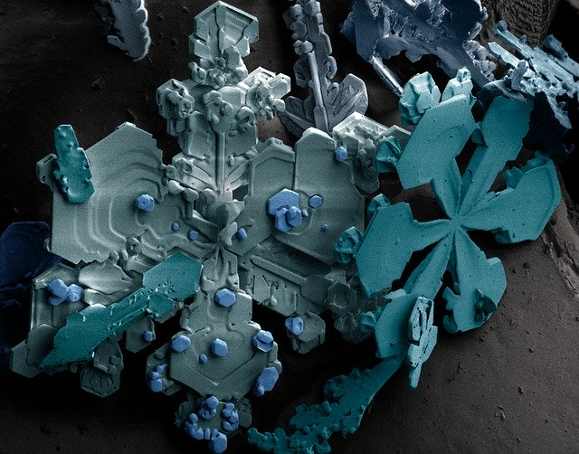

:scale 80%, #123;

]

–

- How can we distinguish between appearances and reality?

–

- What counts as evidence, proof, or disproof and how does logical reasoning work?

–

- What is science and how do we distinguish it from pretenders to science?

–

- What is truth and is it singular or plural?

layout: false

.pull-left[

### .center[.red[*More metaphysical questions…*]]

]

.pull-right[

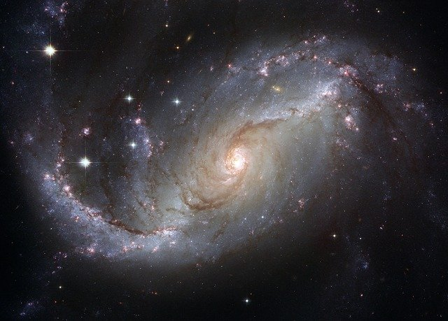

:scale 80%, #123;

]

–

- What sorts of things exist – only matter, or minds/souls/disembodied spirits as well?

–

- What *is* the relationship between minds and brains, and can we build an artificial brain that actually has a mind?

–

- How is human freedom even possible in a world where everything that happens seems to be caused by external forces?

–

- Does God exist, and how might we be able to tell?

–

.caution[ Since philosophy asks us to examine *all* of our assumptions, there can be no fixed method for doing philosophy - historically speaking there have been many different approaches.]

–

Over time, however, certain useful principles have been developed.

–

- Explicitly state our assumptions – this can be a challenge since they *are* assumptions after all.

–

- Draw out their logical implications – do these assumptions fit well with each other and do they clash with other ideas we have?

–

- Make lots of distinctions. (Philosophers have a bad reputation for “splitting hairs,” but we think it is important to be precise in our use of language.)

layout: false ### *Find out more*

[figure not shown]

[figure not shown]

: The Crash Course is a series of short, entertaining and infromative videos produced by the Green bothers John and Hank. Here Hank Green gives his take on what philosophy is.

[figure not shown]

: the second video in the Crash Course Philosophy series outlines the basics of philosophical reasoning and argumentation.

class: center credits

[figure not shown]

:captionpic Rembrandt “Anatomy Lesson”, 50%, #ddd;

#### Credits

*Built with:*

[figure not shown]

:jump Rstudio

[figure not shown]

html presentation framework

*Photos by:*

[figure not shown]

download this presentation or print it

[figure not shown]

: requires a (free) GitHub account.